# Problem Set 03

Your Name Here: Group X

Last updated: 2023-02-09

# Plant Growth Rates

## Tidy Data

We will be using `library(tidyverse)` a lot in this course, and one thing that makes this set of packages function really well is having “tidy” data. This will help you for future data manipulation, cleaning, visualization and analysis.

### Activity

What are the 3 rules that make data tidy?

> Tidy data has 3 rules. 1) Each variable must have its own column. 2) Each observation must have its own row. 3) Each value must have its own cell.

To practice learning how to tidy data, we will will use a dataset from Hautier, Yann et al. (2020), *Fast and furious: Early differences in growth rate drive short-term plant dominance and exclusion under eutrophication.* In this paper, the authors are trying to understand the mechanisms by which diversity is lost under fertilization (i.e., eutrophication). One way they think some species have an advantage is by having a fast early growth rate. Let’s tidy up this dataset so we can look at the trends in growth of different plant species.

Read in the plant growth data `"growthrate_data.csv"`, save it as an object `gr`, and look at the data. What are the dimensions of the resulting tibble?

```r
# FIXME
gr <- read_csv("../data/growthrate_data.csv")
gr
```

```
## # A tibble: 25 × 13
##     plot species day_0 day_13 day_34 day_54 day_61 day_68 day_75 day_90 day_97
##    <dbl> <chr>   <dbl>  <dbl>  <dbl>  <dbl>  <dbl>  <dbl>  <dbl>  <dbl>  <dbl>
##  1     8 H       0.898  0.872  0.67    1.10   1.19   1.5    2.35   4.89   6.26
##  2    12 Al      1.04  NA      1.85    1.05   3.67   2.63   2      6.23   7.34
##  3    15 F       0.464  0.403  0.361   0.41   0.37   0.55   0.71   1.61   5.6
##  4    21 H       0.844  1.24   0.773   0.92   1.62   1.79   2.05   2.63   6.94
##  5    26 Al      0.957  0.987  0.702   1.62  NA      3.9    7.69   8.98   8.93
##  6    30 Al      0.703  0.709  1.62    2      1.55   2.56   4.65   4.34   6.6
##  7    32 Al      0.89   0.624  1.42    0.46   1.29   1.68   2.14   4.21   4.15
##  8    36 Ar      0.376  0.943  1.04    0.42   1.14   1.37   1.54   3.24   5.15
##  9    37 F       0.433  0.523  0.322   0.8    0.61   0.77   0.38   1.71   3.78
## 10    41 An      0.935  0.914  1.04    1.96   1.18   0.89   1.22   3.23   3.39
## # … with 15 more rows, and 2 more variables: day_103 <dbl>, day_112 <dbl>
```

> The data has 25 rows and 13 columns

This appears to be how the scientists entered their data, with columns for plot, species, and then multiple columns for the biomass at the various days they collected their measurements. Unfortunately, this data is not tidy. Why not?

> Observations are in rows, but the variable “biomass” is found in most of the columns, which have repeated “day_” headers. This should have a single column, with date as single column.

To make this data go from wide to long format, you need to use the function `pivot_longer()`. Use this function to create a new dataset called `gr_long` that is tidy, with biomass as the value that runs for a full column.

```r
# FIXME

# There are a few ways to pivot these data. All of which pass the "day_"
# columns into pivot_longer() as the "cols" parameter.
# We show three ways below.

# Pass a string vector specifying all the column names directly
gr_long <- gr |>
  pivot_longer(cols = c("day_0","day_13","day_34","day_54","day_61","day_68",
                        "day_75","day_90","day_97", "day_103", "day_112"),
               names_to ="day",
               values_to ="biomass")
gr_long
```

```
## # A tibble: 275 × 4
##     plot species day     biomass
##    <dbl> <chr>   <chr>     <dbl>
##  1     8 H       day_0     0.898
##  2     8 H       day_13    0.872
##  3     8 H       day_34    0.67
##  4     8 H       day_54    1.10
##  5     8 H       day_61    1.19
##  6     8 H       day_68    1.5
##  7     8 H       day_75    2.35
##  8     8 H       day_90    4.89
##  9     8 H       day_97    6.26
## 10     8 H       day_103   8.89
## # … with 265 more rows
```

```r
# Just specifying the column numbers
gr_long2 <- gr |>
  pivot_longer(cols = c(3:13),
               names_to ="day",
               values_to ="biomass")
gr_long2
```

```
## # A tibble: 275 × 4
##     plot species day     biomass
##    <dbl> <chr>   <chr>     <dbl>
##  1     8 H       day_0     0.898
##  2     8 H       day_13    0.872
##  3     8 H       day_34    0.67
##  4     8 H       day_54    1.10
##  5     8 H       day_61    1.19
##  6     8 H       day_68    1.5
##  7     8 H       day_75    2.35
##  8     8 H       day_90    4.89
##  9     8 H       day_97    6.26
## 10     8 H       day_103   8.89
## # … with 265 more rows
```

```r
# Use the starts_with() function to select all columns beginning with the
# string "day_"
gr_long3 <- gr |>
  pivot_longer(cols = starts_with("day_"),
               names_to ="day",
               values_to ="biomass")
gr_long3
```

```
## # A tibble: 275 × 4
##     plot species day     biomass
##    <dbl> <chr>   <chr>     <dbl>
##  1     8 H       day_0     0.898
##  2     8 H       day_13    0.872
##  3     8 H       day_34    0.67
##  4     8 H       day_54    1.10
##  5     8 H       day_61    1.19
##  6     8 H       day_68    1.5
##  7     8 H       day_75    2.35
##  8     8 H       day_90    4.89
##  9     8 H       day_97    6.26
## 10     8 H       day_103   8.89
## # … with 265 more rows
```

```r
# We can check that these three tibbles are identical with all.equal()
all.equal(gr_long, gr_long2)
```

```
## [1] TRUE
```

```r
all.equal(gr_long, gr_long3)
```

```
## [1] TRUE
```

```r
all.equal(gr_long2, gr_long2)
```

```
## [1] TRUE
```

Now that you have tidied this data, explain why it is tidy. Hint - use the column and row descriptions to explain each of the three rules above.

## Separating Columns

The `separate()` function allows you to split columns of your data into two.

### Activity

You can see our `day` column is a `<chr>`, but we really only need the numeric part (i.e., removing “day_” from each. To be able to plot plant biomass growth through time, in the chunk below, pipe `gr_long` to `separate()` to split this column into two, making sure the column of integers for the day number is called `days`.

```r
# FIXME
gr_long <- gr_long |>
  separate(day, into = c("text", "days"), convert = TRUE)

# You can also remove this extraneous column using this the [] and - the column of interest
gr_long <- gr_long[,-3]
gr_long
```

```
## # A tibble: 275 × 4
##     plot species  days biomass
##    <dbl> <chr>   <int>   <dbl>
##  1     8 H           0   0.898
##  2     8 H          13   0.872
##  3     8 H          34   0.67
##  4     8 H          54   1.10
##  5     8 H          61   1.19
##  6     8 H          68   1.5
##  7     8 H          75   2.35
##  8     8 H          90   4.89
##  9     8 H          97   6.26
## 10     8 H         103   8.89
## # … with 265 more rows
```

```r
# Alternately, you can use select() with - to do this step in a pipe:
gr_long2 <- gr_long2 |>
  separate(day, into = c("text", "days"), convert = TRUE) |>
  select(-text)

# A fourth method to is to remove "day_" from `day` with `str_remove()` via
# `mutate()`
#
# gr_long <- gr_long |>
#   mutate(days = as.numeric(str_remove(day, "day_")), .keep = "unused")
```

Check the structure of your modified tibble. You may notice that your new column `days` is still a character. If so, go back and fix the code above so it is no longer a character. Check the help file for `separate()`.

## Data Counts

Another way to get counts by group uses `group_by()` and `tally()`, which are part of tidyverse. `group_by()` splits data by factors (most commonly, but numerics will work as well) and `tally()` adds up the number of observations in each of those groups. Similarly, the `count()` function does both steps in one, grouping by the columns inside `()` and then counting.

### Activity

In the chunk below, pipe `gr_long` to `group_by()`, grouping by species. Then pipe that to `tally()`. `tally()` does not require any arguments when used this way. Also try the same using `count()`.

```r
#FIXME
gr_long |> group_by(species) |> tally()
```

```
## # A tibble: 5 × 2
##   species     n
##   <chr>   <int>
## 1 Al         55
## 2 An         55
## 3 Ar         55
## 4 F          55
## 5 H          55
```

```r
gr_long |> count(species)
```

```
## # A tibble: 5 × 2
##   species     n
##   <chr>   <int>
## 1 Al         55
## 2 An         55
## 3 Ar         55
## 4 F          55
## 5 H          55
```

Do you have equal sample size across all species?

> Yes, 55.

## NA’s

Missing data can sometimes throw off our estimates if we are not sure if data is there or not. R will code blank cells in your dataset as `NA` when you read in your data. `NA`’s are explicit if you can see them in your dataset, and they are implicit if a row does not exist in a dataset when a data value is missing. Explicit `NA`’s will be counted by `tally()`.

### Activity

Our code above indicates that we have equal sample size in our data for each species, however you may have noticed that in our initial dataset there are some `NA`’s. Do we still have `NA`’s in our dataset?

You can type `View(gr_long)` into the R console to investigate `gr_long` and find out. In general, don’t put `View()` into a chunk or R will pause when knitting.

> Yes we still have NA’s.

The function `is.na()` returns true when a value is `NA`. By summing the number of `TRUE` `NA`’s, you can see how many there are. Below write a line of code that sums the result of `is.na()` applied to the `biomass` column.

```r
# FIXME

sum(is.na(gr_long$biomass))
```

```
## [1] 6
```

How many `NA`’s are there?

> 6

So based on this, do we really have equal sample size? Why not?

> We do not have equal sample size because we have explicit `NA`’s and `tally()` is counting up the number of rows per species. Thus the explicit `NA`’s fill in a row, and it looks like the sample size is even.

The `drop_na()` function allows you to drop rows that have `NA`s in them in order to check to see if your sample size is equal. In the chunk below, pipe `gr_long` to `drop_na()` and save it as a new dataset called `gr_long2`. Then re-tally your data to see if you have equal sample size across all species.

```r
#FIXME
gr_long2 <- gr_long |>
  drop_na()

gr_long2 |> group_by(species) |> tally()
```

```
## # A tibble: 5 × 2
##   species     n
##   <chr>   <int>
## 1 Al         52
## 2 An         53
## 3 Ar         54
## 4 F          55
## 5 H          55
```

```r
gr_long2 |> count(species)
```

```
## # A tibble: 5 × 2
##   species     n
##   <chr>   <int>
## 1 Al         52
## 2 An         53
## 3 Ar         54
## 4 F          55
## 5 H          55
```

> No, now we see we have different sample sizes per species.

## Data Exploration

Let’s look at this growth rate data to see if we see any differences between species.

### Activity

Using your object `gr_long2`, create a plot that shows the biomass per species at each date as a scatter plot, and draw a straight line through the average of all points per species using `geom_smooth()`. Make sure each species is differentiated by assigning the color aesthetic to `species` (inside `aes()`), which will also plot a separate line for each. Also make sure to clean up your plot by adding a little jitter, if your points are strongly overlapping.

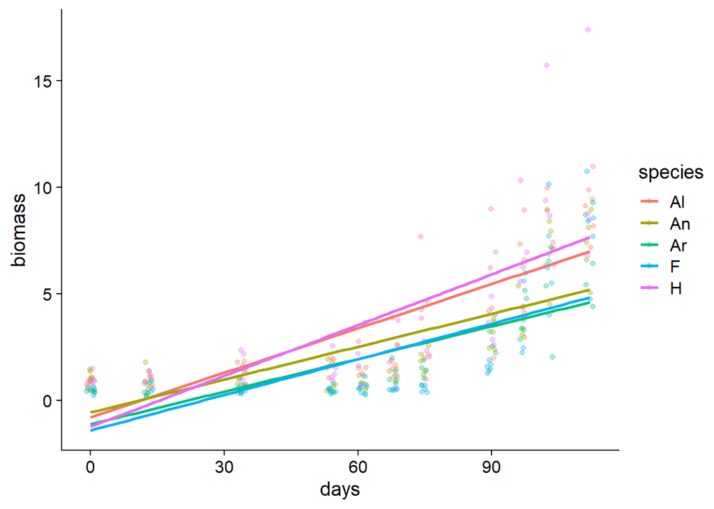

```r
# FIXME
ggplot(gr_long2, aes(x = days, y = biomass, color = species))+
  geom_point(position = position_jitter(width = 1), alpha = 1/3)+
  geom_smooth(method = "lm", se = FALSE)
```

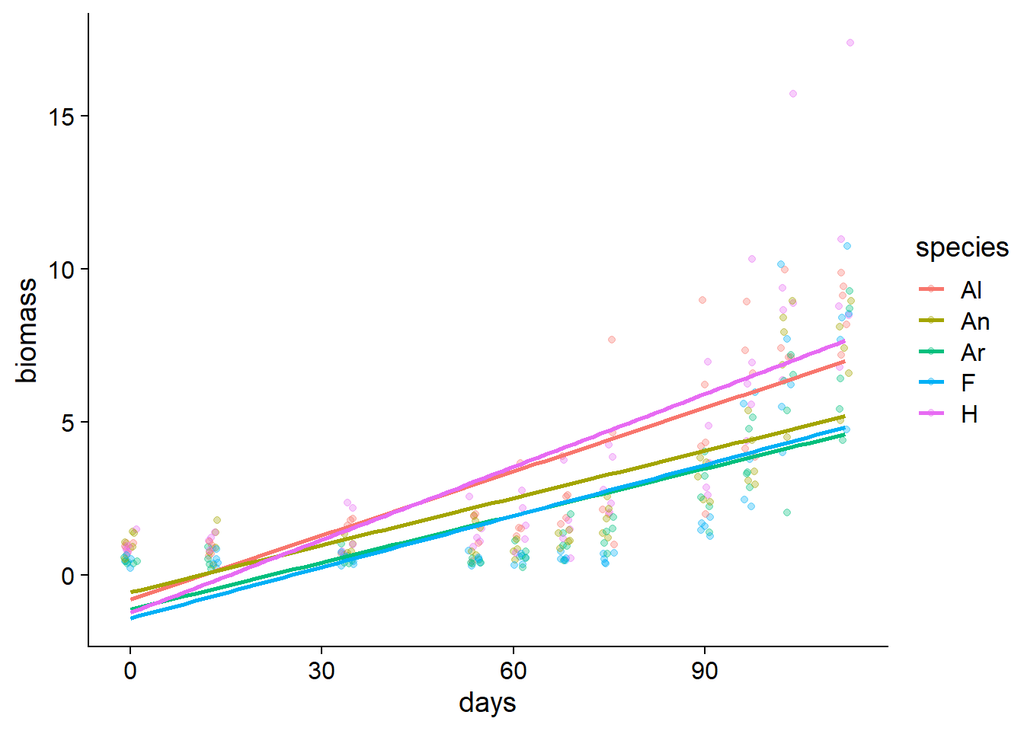

```r
# You can get rid of the message `geom_smooth()` using formula 'y ~ x' by
# explicitly using the formula argument:

ggplot(gr_long2, aes(x = days, y = biomass, color = species))+
  geom_point(position = position_jitter(width = 1), alpha = 1/3)+
  geom_smooth(formula = y ~ x, method = "lm", se = FALSE)
```

Which species appears to have the fastest rate of growth (biomass change per time)?

> H and Al.

Look back at the plot you just made. It appears a straight line, linear fit doesn’t model the data very well. Growth rate appears to be flat for early days and then increases exponentially. In addition, the linear fit is predicting negative biomasses for early timepoints. Let’s transform how our data is plotted to see if we can improve the fit. Make a new plot and add the geom `scale_y_log10()` to plot the y-axis on a log10 scale.

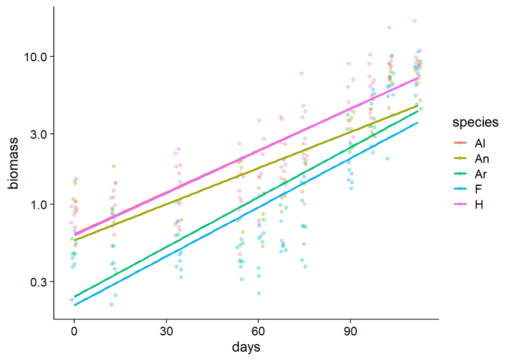

```r
# FIXME
ggplot(gr_long2, aes(x = days, y = biomass, color = species)) +
  geom_point(position = position_jitter(width = 1), alpha = 1/3) +
  geom_smooth(formula = y ~ x, method = "lm", se = FALSE) +
  scale_y_log10()
```

Does a log transformation of biomass improve the linear fit of the model?

> Yes, the fit looks much more appropriate now. The general patterns seems to be very similar.

# Rainout Experiment

In this next section, we will be practicing data manipulation and exploration. We will work with two files that contain data related to a rainout experiment. Changes in precipitation are commonly predicted with climate change, so rainout experiments are used to examine how different proposed future precipitation conditions (i.e., in our case high or low rain reduction) influences plant species composition and biomass.

The first dataset (`"rainout_plots.csv"`) describes plot-level data. This experiment contains 8 subplots per plot. Thus these plot-level data contains plot and subplot identities, as well as only a single value per subplot for each of its variables (e.g., light availability, biomass) as these are collected at the subplot level. We will also work with a dataset that contains information about species *within* each subplot called `"rainout_plantspecies_presence.csv"`. There will be multiple observations per subplot in this dataset because the unique species in each subplot was recorded.

Let’s start with the plant composition data. Read in `"rainout_plantspecies_presence.csv"` and save it to an object called `comp`. Look at the structure of this tibble.

```r
# FIXME
comp <- read_csv("../data/rainout_plantspecies_presence.csv")
str(comp)
```

```
## spc_tbl_ [409 × 3] (S3: spec_tbl_df/tbl_df/tbl/data.frame)
##  $ plot_no: num [1:409] 1 1 1 1 1 1 1 1 1 1 ...
##  $ subplot: num [1:409] 1 1 1 2 2 2 2 2 2 3 ...
##  $ species: chr [1:409] "poapra" "cortri" "andger" "poapra" ...
##  - attr(*, "spec")=
##   .. cols(
##   ..   plot_no = col_double(),
##   ..   subplot = col_double(),
##   ..   species = col_character()
##   .. )
##  - attr(*, "problems")=<externalptr>
```

## Summarizing

One very important tool you will learn from the tidyverse is how to summarize your data. We will use the `summarize()` function quite a bit in this course, so let’s get some practice. One thing we might want to know about is how many unique species are in each subplot within each plot. That way we can start to make predictions about how rain exclusion influences species richness. Using `group_by()` and `summarize()`, calculate the number of unique species per subplot within each plot in `comp`. Save the new object as `richness`, and also name the new variable `richness`. Hint `(length(unique(<variable-of-interest>)))` will give you the number of rows that are unique within the groups you have set, which equates to the number of unique species, or richness, per subplot.

### Activity

```r
# FIXME

richness <- comp |>
  group_by(plot_no, subplot) |>
  summarize(richness = length(unique(species)))
richness
```

```
## # A tibble: 96 × 3
## # Groups:   plot_no [12]
##    plot_no subplot richness
##      <dbl>   <dbl>    <int>
##  1       1       1        3
##  2       1       2        6
##  3       1       3        4
##  4       1       4        5
##  5       1       5        5
##  6       1       6        7
##  7       1       7        7
##  8       1       8        7
##  9       2       1        7
## 10       2       2        4
## # … with 86 more rows
```

```r
# You can get rid of the message `summarize()` has grouped output by 'plot_no'
# like this:
richness2 <- comp |>
  group_by(plot_no, subplot) |>
  summarize(richness = length(unique(species)),
            .groups = "drop")
richness2
```

```
## # A tibble: 96 × 3
##    plot_no subplot richness
##      <dbl>   <dbl>    <int>
##  1       1       1        3
##  2       1       2        6
##  3       1       3        4
##  4       1       4        5
##  5       1       5        5
##  6       1       6        7
##  7       1       7        7
##  8       1       8        7
##  9       2       1        7
## 10       2       2        4
## # … with 86 more rows
```

## Joining

One of the most common things you will do in your data cleaning and exploration stage is join datasets together. This will become especially important if you store your data as separate, smaller files. In our case, we need to join our `richness` object with our plot-level information so we can examine how richness changes with our two rainout treatments (e.g., high rain removal and low rain removal).

### Activity

Read in the plot-level data , and save it to an object called `plot_ids`.

```r
# FIXME
plot_ids <- read_csv("../data/rainout_plots.csv")
plot_ids
```

```
## # A tibble: 96 × 5
##    plot_no subplot rain_removal light_at_groundlevel biomass
##      <dbl>   <dbl> <chr>                       <dbl>   <dbl>
##  1       1       1 high                           90     531
##  2       1       2 high                           92     530
##  3       1       3 high                          102     623
##  4       1       4 high                           57     574
##  5       1       5 high                          129      75
##  6       1       6 high                           82     616
##  7       1       7 high                          151     526
##  8       1       8 high                           54     341
##  9       2       1 high                           91     426
## 10       2       2 high                           96      94
## # … with 86 more rows
```

As we discussed in lecture, there are many different functions for joining in the tidyverse. We will focus on `left_join()` here because you can use this for most joining you need to do, and switch the order of the datasets you are joining depending on your need. I.e., `left_join(d1, d2)` is the same as `right_join(d2, d1)`.

Join your plot level data to your species richness data using `left_join()`. You can save this as the same object that the richness was saved as previously, given this is the data you are building upon. Try doing this in two different ways, one where you specify the columns you want to join by, and one where you don’t and let `left_join()` pick the columns that automatically match. This should help you see the power of these joining functions.

```r
# FIXME
richness <- richness |>
  left_join(plot_ids, by = c("plot_no", "subplot"))
richness
```

```
## # A tibble: 96 × 6
## # Groups:   plot_no [12]
##    plot_no subplot richness rain_removal light_at_groundlevel biomass
##      <dbl>   <dbl>    <int> <chr>                       <dbl>   <dbl>
##  1       1       1        3 high                           90     531
##  2       1       2        6 high                           92     530
##  3       1       3        4 high                          102     623
##  4       1       4        5 high                           57     574
##  5       1       5        5 high                          129      75
##  6       1       6        7 high                           82     616
##  7       1       7        7 high                          151     526
##  8       1       8        7 high                           54     341
##  9       2       1        7 high                           91     426
## 10       2       2        4 high                           96      94
## # … with 86 more rows
```

```r
#Also
richness |>
  left_join(plot_ids)
```

```
## # A tibble: 96 × 6
## # Groups:   plot_no [12]
##    plot_no subplot richness rain_removal light_at_groundlevel biomass
##      <dbl>   <dbl>    <int> <chr>                       <dbl>   <dbl>
##  1       1       1        3 high                           90     531
##  2       1       2        6 high                           92     530
##  3       1       3        4 high                          102     623
##  4       1       4        5 high                           57     574
##  5       1       5        5 high                          129      75
##  6       1       6        7 high                           82     616
##  7       1       7        7 high                          151     526
##  8       1       8        7 high                           54     341
##  9       2       1        7 high                           91     426
## 10       2       2        4 high                           96      94
## # … with 86 more rows
```

## More Summarizing

Along with the minimum, maximum, and range, two of the simplest and most common descriptive statistics are means and standard deviations.

### Activity

Calculate the mean and standard deviation for species richness for each plot. Use `group_by()` and `summarize()`. Save this as a new object called `mean_richness`.

```r
# FIXME
mean_richness <- richness |>
  group_by(plot_no) |>
  summarize(mean = mean(richness),
            sd = sd(richness))
mean_richness
```

```
## # A tibble: 12 × 3
##    plot_no  mean    sd
##      <dbl> <dbl> <dbl>
##  1       1  5.5  1.51
##  2       2  6    1.69
##  3       3  3.12 0.835
##  4       7  2.75 1.04
##  5       8  5.12 1.36
##  6      11  2.75 0.463
##  7      12  5.12 1.55
##  8      13  2.88 0.641
##  9      14  5.75 1.67
## 10      16  6    1.69
## 11      21  3.38 1.51
## 12      22  2.62 0.744
```

To visualize whether there are consistent differences in richness between rainout treatments, we will plot our data.

### Activity

Create a graph that shows how rain removal influences the average species richness using a scatter plot. Color your points by plot number in the `aes()`. Add transparency and/or jitter to make sure you can see all points clearly. Because plots are a category, make sure it is being treated as a factor when you make your plot. Feel free to fix up the axis labels or choose a new color scheme if you wish.

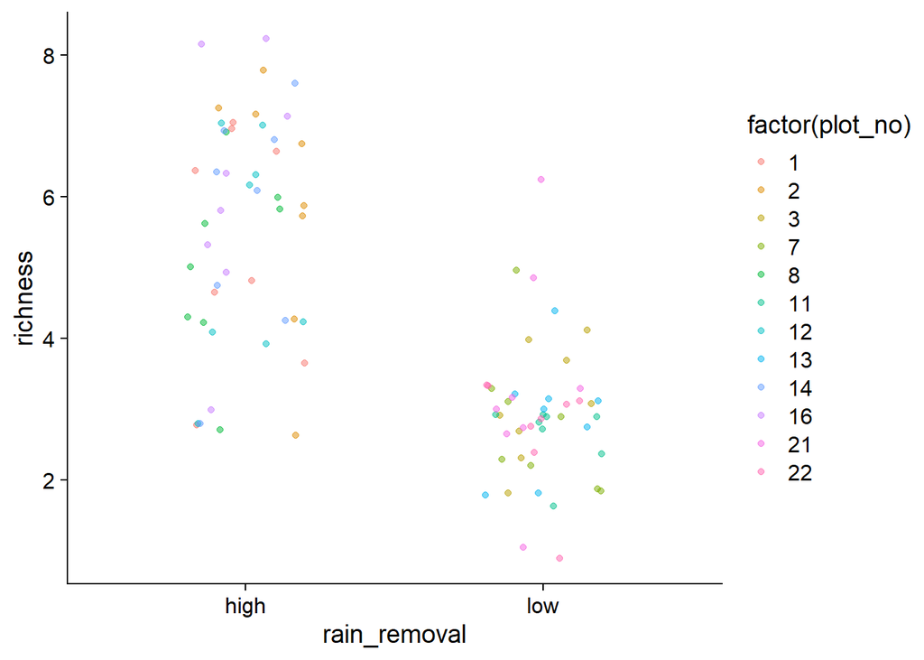

```r
# FIXME
ggplot(richness, aes(x = rain_removal, y = richness,
                     color = factor(plot_no))) +
  geom_point(position = position_jitter(width = 0.2), alpha = 1/2)
```

With a scatterplot and this number of plots, it is difficult to see the trends per plot. Let’s try a boxplot instead. Use `geom_boxplot` and specify different colors for different plot numbers in the `aes()`.

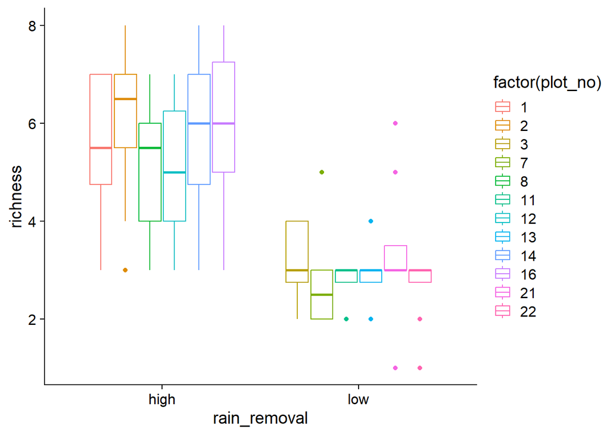

```r
# FIXME

ggplot(richness, aes(x = rain_removal, y = richness,
                     color = factor(plot_no))) +
  geom_boxplot()
```

Notice how setting `color =` in the aesthetics causes ggplot to split the data into groups automatically and apply separate lines or boxplots to those data. This is a very powerful feature of ggplot that makes it possible to generate very complex plots very easily. In contrast, imagine doing 12 separate linear regressions, adding them one by one to the plot and keeping track of all their different colors.

# Cleaning up the Spider Size Dimorphism data again

In the last problem set, you spent some time cleaning up the spider size dimorphism data using base R functions. This week, we will so some of the same operations, but use functions from the tidyverse. While it is very good to know and be able to use base R functions, the same set of operations can be accomplished using tidy functions in pipes. This makes for more compact code that requires less deciphering of logical subsetting (all the `[]` notation).

### Activity

Start by loading the original `Size_Dimprphism.xlsx` file into an R object. Use the original version with the data entry errors, not the cleaned version that you exported.

```r
## FIXME
M <- read_excel("../data/Size_Dimorphism.xlsx")
```

Counting the numbers of groups is easily accomplished by using the `tally()` function of grouped data like you saw above. In the next chunk, use `group_by()` to group the data by `Species` and `Sex` and then pipe this result to `tally()`

```r
## FIXME
M |>
  count(Species, Sex)
```

```
## # A tibble: 9 × 3
##   Species          Sex       n
##   <chr>            <chr> <int>
## 1 Nephila_clavipes F        48
## 2 Nephila_clavipes M        50
## 3 Nephila_clavipes f         2
## 4 Pardosa ramulosa M         1
## 5 Pardosa_ramulosa F        48
## 6 Pardosa_ramulosa M        45
## 7 Pardosa_ramulosa f         2
## 8 Pardosa_ramulosa m         3
## 9 Pardosa_ramuloso M         1
```

You should be able to easily detect the mis-coded `Sex` variables and spelling errors in the `Species` names.

We will fix the `Sex` variable first. Because you currently have a mix of lower and upper case, and we want all uppercase, we can use the built-in `toupper()` function which makes a string all uppercase. There is a similar `tolower()` function, if you happen to want all lower case.

In this chunk, mutate `Sex` using `toupper()`. Overwrite your R object from above with the output. Then use the same tallying code your wrote above to check that you now only have `F` and `M` in the `Sex` column.

```r
## FIXME
M <- M |>
  mutate(Sex = toupper(Sex))

M |>
  count(Species, Sex)
```

```
## # A tibble: 6 × 3
##   Species          Sex       n
##   <chr>            <chr> <int>
## 1 Nephila_clavipes F        50
## 2 Nephila_clavipes M        50
## 3 Pardosa ramulosa M         1
## 4 Pardosa_ramulosa F        50
## 5 Pardosa_ramulosa M        48
## 6 Pardosa_ramuloso M         1
```

You should now see that just two observations of `Species` are incorrect. There are a few ways to “find and replace” strings in R. The `stringr` package, which is loaded automatically as part of the tidyverse has a series of functions that start with `str_` to work with strings (find, replace, subset, etc.).

Have a look through the help files for the `stringr` package to see what all is possible.

We will use `str_replace()` to replace the misspelled names. `str_replace()` has the following basic syntax:

```r
zz <- c("x_1", "x_2")
str_replace(zz, "x", "xyz")
```

```
## [1] "xyz_1" "xyz_2"
```

This code replaces `x` with `xyz`. In the following chunk, overwrite `Species` with a `mutate()`ed version of itself passed through `str_replace()` where you correct the two spellings that are incorrect (you will mutate Species twice, once for each correction). Then use the same code as above to tally the data and check that the four groups now have 50 observations each.

```r
## FIXME
M <- M |>
  mutate(Species = str_replace(Species, "Pardosa ramulosa", "Pardosa_ramulosa"),
         Species = str_replace(Species, "Pardosa_ramuloso", "Pardosa_ramulosa"))
M |>
  count(Species, Sex)
```

```
## # A tibble: 4 × 3
##   Species          Sex       n
##   <chr>            <chr> <int>
## 1 Nephila_clavipes F        50
## 2 Nephila_clavipes M        50
## 3 Pardosa_ramulosa F        50
## 4 Pardosa_ramulosa M        50
```

Your data is clean. At this point in the analysis, you could export your cleaned data to a new file. Alternately, you could just have these steps at the beginning of your Rmd file with the analysis pipeline and just let me run each time your Rmd file is knitted. Either way would work, and there are benefits to both approaches. With the former, you will have a cleaned version of your data to work with (e.g., import) for later steps in the analysis. This is not ideal because it makes more files to keep track of. With the latter, you will have a full record of the steps you took to clean the data. The downside is that you need to make sure to run all the code each time you knit to be sure to have the corrected data. If you are analyzing data via a set of separate files, this might be impractical (e.g., if your 2nd analysis file needs the cleaned data).